# Investigation in Students Performance

## by Abraam Emad

## Investigation Overview

In our investigation. Explore the features that's effect on the performance of students in math, reading, writing and overall.

## Dataset Overview

In our dataset. Consist of 1,000 observation and 8 attributes and will create overall attribute that's the total score in reading, writing and math score.

## The overall performance of students

- In average student had score 70 and the most score between 60-80 and there is some outliers less than 30.

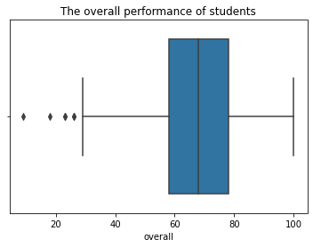

```python
# use box plot of overall
sb.boxplot(students_df["overall"])
plt.title("The overall performance of students")
plt.show();
```

## The overall performance of studends in each group

- Group E has the best students performance.

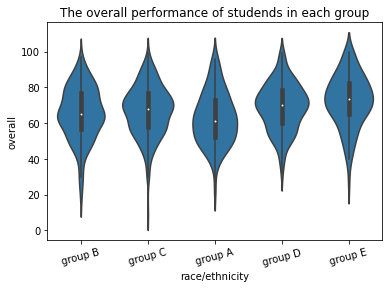

```python
# Use violinplot in groups and overall score
sb.violinplot(data=students_df, x='race/ethnicity', y='overall', color=base_color, innner=None)
plt.title("The overall performance of studends in each group")
plt.xticks(rotation=15);
```

## The overall performance of studends for each parental level of education

- Students had master's degree has the best performance.

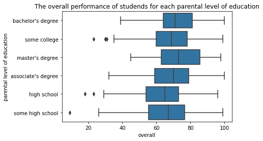

```python
# Use boxplots in parental level of education and overall
sb.boxplot(data=students_df, y='parental level of education', x='overall', color=base_color)
plt.title("The overall performance of studends for each parental level of education")
plt.show();
```

## Reading and writing score for each gender

- Females are better than males in reading and writing scores.

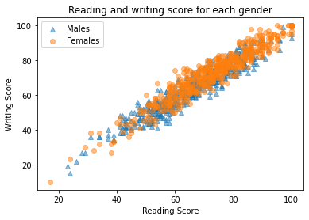

```python
# plot gender, reading and writing score
gender_markers = [['male', '^'],
               ['female', 'o']]

for gen, marker in gender_markers:
    df_gender = students_df[students_df['gender'] == gen]
    plt.scatter(data = df_gender, x = 'reading score', y = 'writing score', marker = marker, alpha = .5)
plt.legend(['Males','Females'])
plt.title("Reading and writing score for each gender")
plt.xlabel('Reading Score')
plt.ylabel('Writing Score');
```

## Reading and writing score for each gender and completed test preparation course

- All Students that's complete test preparation course had reading and writing score better than othrs.

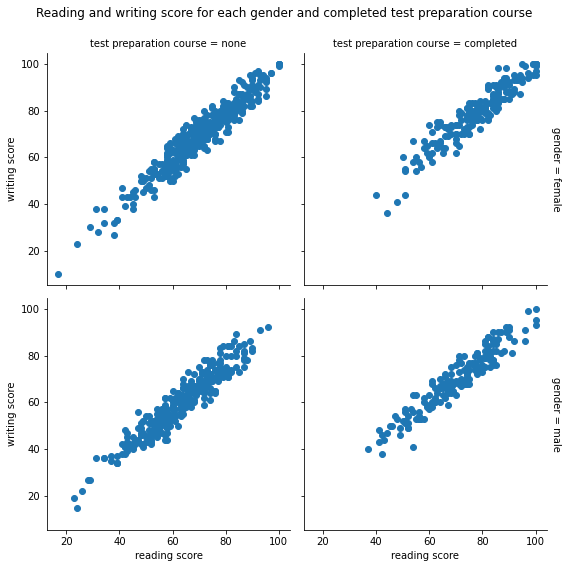

```python
# plot gender, test preparation course, reading and writing score
g = sb.FacetGrid(data = students_df, col = 'test preparation course', row = 'gender', size = 4,
                margin_titles = True)
g.map(plt.scatter, 'reading score', 'writing score')
g.fig.subplots_adjust(top=.90)
g.fig.suptitle('Reading and writing score for each gender and completed test preparation course');
```

## Math score and groups for each gender

- Males students in all groups had math score better than females.

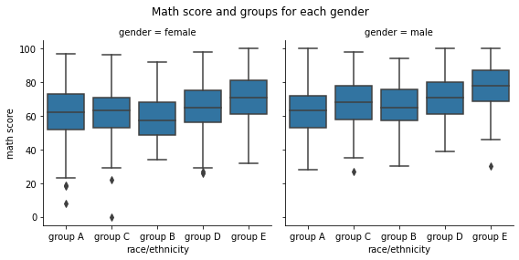

```python
# plot gender, groups and math score
g = sb.FacetGrid(data = students_df, col = 'gender', size = 4)
g.map(sb.boxplot, 'race/ethnicity', 'math score')
g.fig.subplots_adjust(top=.85)
g.fig.suptitle('Math score and groups for each gender');
```

## Overall score and lunch for each gender

- In Average males had standard lunch higher than others in overall, but females had standard lunch less than others in overall.

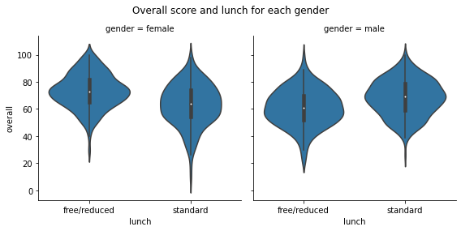

```python
# plot gender, lunch and overall score
g = sb.FacetGrid(data = students_df, col = 'gender', size = 4)
g.map(sb.violinplot, 'lunch', 'overall')
g.fig.subplots_adjust(top=.85)
g.fig.suptitle('Overall score and lunch for each gender');
```

## Conclusion

- Overall performance between 60-80
- Females are better than males in overall performance.
- Females are better than males in reading and writing but males are better in math.
- Group E is the best group between students.
- Students had master's degrees are better than others.
- Students that completed the test preparation course are better than others.
- Males who had standard lunch are better than others, but females who had free/reduced lunch are better than others.